# Modelos Lineales

ronny hdez_mora

23 agosto, 2017

# ¿Qué son modelos lineales?

De manera mega resumida y como su palabra lo dice, son métodos que utilizamos para modelar la relación entre una variable respuesta numérica y sus predictores numéricos o categóricos.

En este caso, modelar implica dar un paso más allá y movernos de describir relaciones entre variables a tratar de predecir comportamientos de los datos.

## ¿Qué hay con los modelos lineales generalizados?

Los modelos lineales como las regresiones, ANOVAS, ANCOVAS son usados para predecir una variable respuesta (lo que va en el eje Y) con distribución normal a partir de un conjunto de variables predictivas (lo que va en el eje X) continuas o categóricas

## Entonces, ¿Qué vamos a ver en este tutorial?

- La exploración de datos para confirmar supuestos.
- Regresión
- Tal vez ANOVA & ANCOVA

# ¿Qué hago primero?

Se parte del hecho que ya los datos tomados vienen con un diseño experimental pensado previo al análisis y que por ende las relaciones entre las variables se encuentran dadas al menos en el diseño.

Sin embargo para proceder con métodos de modelos lineales debemos de cumplir con ciertos supuestos que son los que verificaremos con la exploración de datos.

## Exploración de datos:

Podemos revisar el set de datos:

```r
str(iris)
```

```
## 'data.frame':    150 obs. of  5 variables:
##  $ Sepal.Length: num  5.1 4.9 4.7 4.6 5 5.4 4.6 5 4.4 4.9 ...
##  $ Sepal.Width : num  3.5 3 3.2 3.1 3.6 3.9 3.4 3.4 2.9 3.1 ...
##  $ Petal.Length: num  1.4 1.4 1.3 1.5 1.4 1.7 1.4 1.5 1.4 1.5 ...
##  $ Petal.Width : num  0.2 0.2 0.2 0.2 0.2 0.4 0.3 0.2 0.2 0.1 ...
##  $ Species     : Factor w/ 3 levels "setosa","versicolor",..: 1 1 1 1 1 1 1 1 1 1 ...
```

Hacer un gráfico para revisar alguna relación:

```r
plot_1 <- ggplot(iris, aes(x = Sepal.Length, y = Petal.Length)) +
        geom_point() +
        geom_smooth(method = lm)
```

## Construcción del modelo:

Vamos a utilizar un set de datos que se llama iris. Si quieren ver cuáles datasets vienen en la base de R pueden correr el comando.

```r
data()
```

Acá, para llamar a iris, lo podemos hacer un objeto:

```r
lm(iris$Sepal.Length ~ iris$Petal.Length)
```

```
##
## Call:
## lm(formula = iris$Sepal.Length ~ iris$Petal.Length)
##
## Coefficients:
##       (Intercept)  iris$Petal.Length
##            4.3066             0.4089
```

Lo anterior nos dará los coeficientes del modelo, por lo qué, es mejor hacer el modelo un objetivo definido en nuestro entorno y luego aplicarle una función de resumen:

```r
modelo_1 <- lm(iris$Sepal.Length ~ iris$Petal.Length)
summary(modelo_1)
```

```
##
## Call:
## lm(formula = iris$Sepal.Length ~ iris$Petal.Length)
##
## Residuals:
##      Min       1Q   Median       3Q      Max
## -1.24675 -0.29657 -0.01515  0.27676  1.00269
##
## Coefficients:
##                   Estimate Std. Error t value Pr(>|t|)
## (Intercept)        4.30660    0.07839   54.94   <2e-16 ***
## iris$Petal.Length  0.40892    0.01889   21.65   <2e-16 ***
## ---
## Signif. codes:  0 '***' 0.001 '**' 0.01 '*' 0.05 '.' 0.1 ' ' 1
##
## Residual standard error: 0.4071 on 148 degrees of freedom
## Multiple R-squared:   0.76,  Adjusted R-squared:  0.7583
## F-statistic: 468.6 on 1 and 148 DF,  p-value: < 2.2e-16
```

- Ecuación del modelo:

**Sepal.Length = 4.30 + 0.40 * Petal.Length**

## Verificación supuestos del modelo

Para poder confiar en nuestro modelo, debemos de corroborar los supuestos, como:

-Independencia -Homocedasticidad -Normalidad.

```r
par(mcol = c(2,2))
```

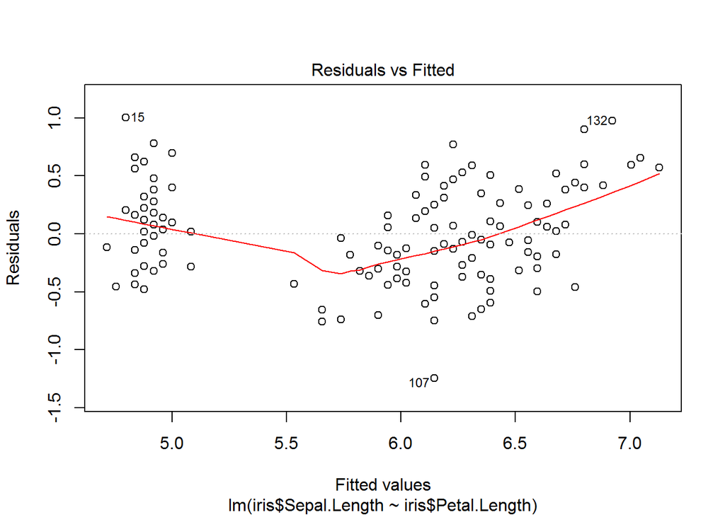

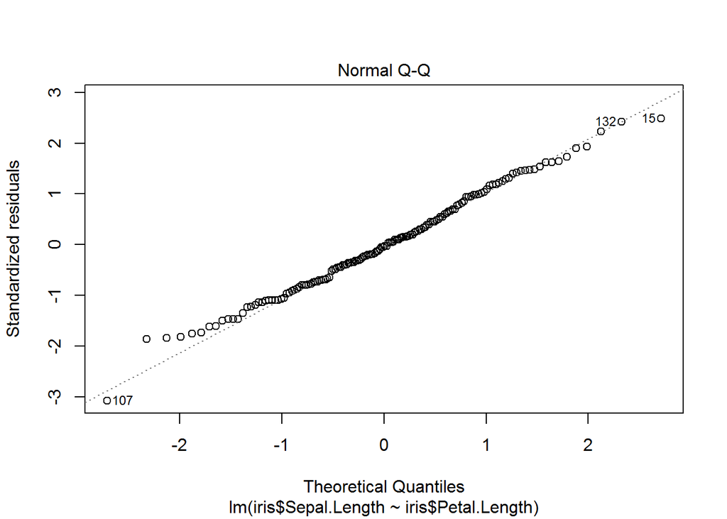

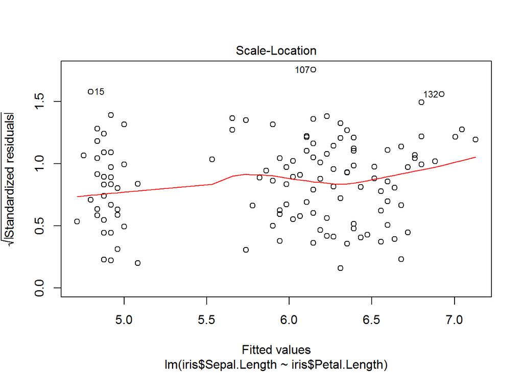

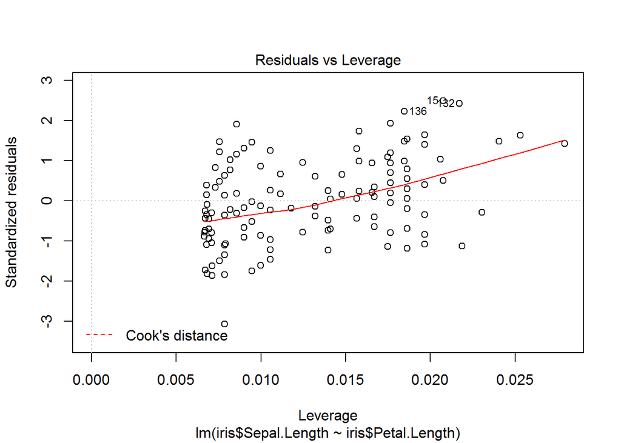

```r
plot(modelo_1)
```

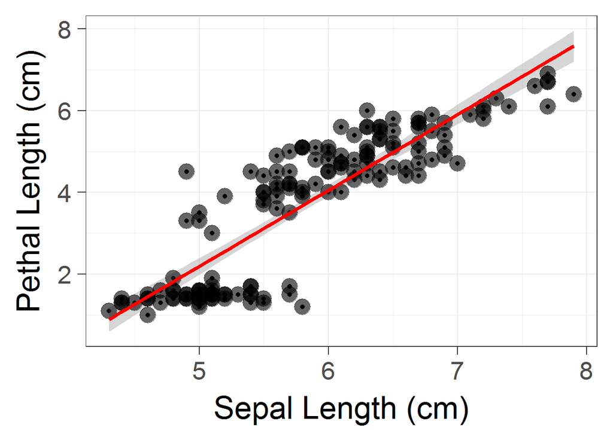

```r
theme_set(theme_bw(base_size = 26)) # Para configurar tema del gráfico
# Gráfico "más bonito"
plot_1 + geom_point(shape = 19,size = 6,alpha = 0.6,
                    colour = "black") +
        scale_colour_hue(l = 50) +
        labs(x = "Sepal Length (cm)",y = "Pethal Length (cm)") +
        geom_smooth(method = lm,
                se = FALSE,
                fullrange = FALSE,colour = "red",alpha = 0.1, size = 1.5)
```